# Google Play Store App Ratings, Installs and Pricing Analysis

ETC5513 Assignment 3 — Group 16

Hanwen Liu, Pratyush Kumar, Chenuli Muthukuda Arachchige, Shenyu He

## Problem Introduction

- The Google Play Store hosts millions of apps, making it one of the most competitive digital marketplaces in the world.
- For developers, understanding **what drives app success** is critical to maximising reach and user satisfaction.
- Two key success metrics: **user ratings** and **install counts**.

**Research question:** What factors influence mobile app success in terms of ratings and installs, and how do pricing and category affect performance?

## Dataset Description

- **Source:** Google Play Store Apps dataset (Kaggle), collected via web scraping
- **`googleplaystore.csv`** — 10,841 raw records, reduced to **8,196 unique apps** after cleaning, across **33 categories**
  - Key variables: `Rating`, `Installs`, `Type` (Free/Paid), `Price`, `Category`
- **`googleplaystore_user_reviews.csv`** — over 64,000 user reviews with sentiment scores

Records with missing ratings and duplicate apps were removed to ensure data quality.

## Methodology — Data Cleaning

Cleaning was performed in R using the `tidyverse` package:

- Removed records with **missing ratings**
- Converted `Installs` from text (e.g. “1,000+”) to **numeric** values
- Cleaned `Price` (removed the `$` symbol)
- Removed **duplicate apps**, retaining the first occurrence

**Result: 8,196 unique apps** retained for analysis.

## Methodology — Summary Statistics

| Variable | Mean | Median | SD |
| --- | --- | --- | --- |
| Rating | 4.17 | 4.3 | 0.54 |
| Reviews | 255,251.47 | 3,004.0 | 1,985,593.85 |
| Installs | 9,165,089.72 | 100,000.0 | 58,250,865.45 |

- Ratings are consistently high (mean **4.17**, low spread)
- Reviews & installs are **heavily skewed** — a few apps dominate the averages

## Methodology — Dataset Composition

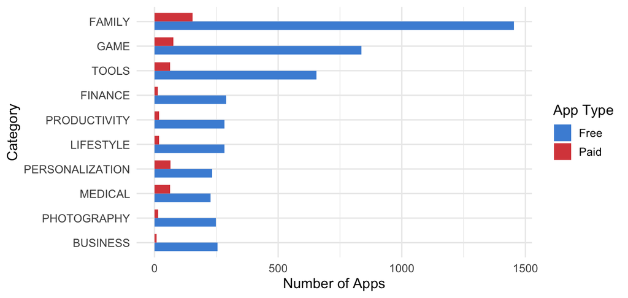

- Free apps **vastly outnumber** paid apps in every category
- Family, Game and Tools are the largest categories

## Free vs Paid: Install Distribution

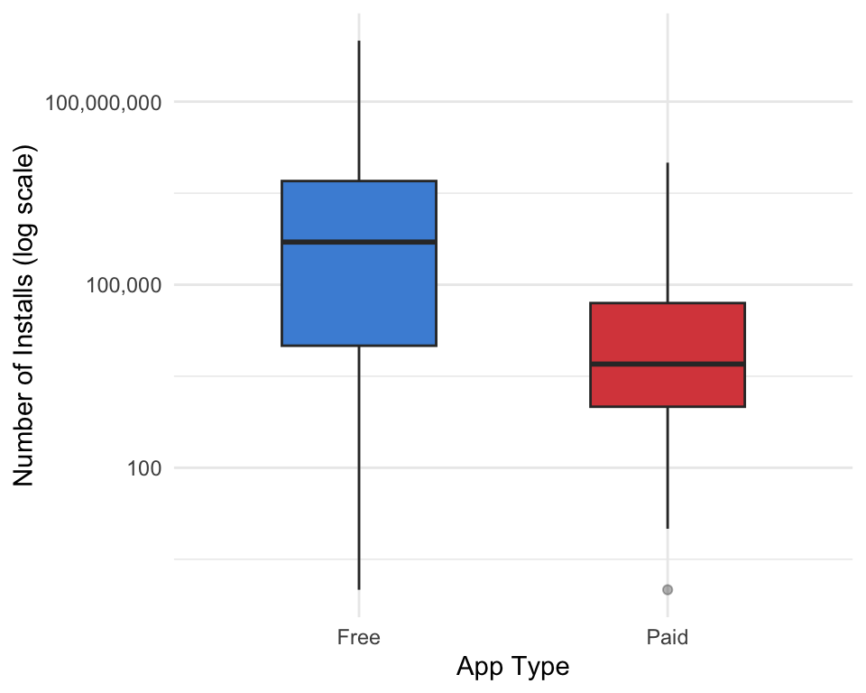

- Free apps achieve substantially higher median install counts
- Paid apps cluster at lower installs with a compressed distribution
- Some paid apps struggle to gain meaningful traction
- Pricing strategy is a fundamental driver of app reach

## Results: Free vs Paid by Category

| Category | Free Apps | Paid Apps | Avg Rating (Free Apps) | Avg Rating (Paid Apps) |
| --- | --- | --- | --- | --- |
| FAMILY | 1454 | 154 | 4.17 | 4.28 |
| GAME | 836 | 76 | 4.24 | 4.37 |
| TOOLS | 655 | 63 | 4.03 | 4.17 |
| FINANCE | 289 | 13 | 4.13 | 3.83 |
| LIFESTYLE | 283 | 18 | 4.08 | 4.25 |
| PRODUCTIVITY | 283 | 18 | 4.18 | 4.21 |
| BUSINESS | 254 | 9 | 4.10 | 4.08 |
| PHOTOGRAPHY | 248 | 15 | 4.17 | 4.01 |
| PERSONALIZATION | 233 | 65 | 4.30 | 4.45 |
| MEDICAL | 227 | 63 | 4.15 | 4.23 |

- Family and Game dominate in app volume across all categories
- Personalization and Game emerge as the highest-rated categories
- Paid apps achieve marginally higher ratings than free apps overall
- Finance is a notable exception where free apps outperform paid

## Discussion

- Pricing strategy shapes app performance, but its effect depends on the success metric.
- Free apps maximise reach — users download more readily with no upfront cost.
- Paid apps tend to earn slightly higher ratings, suggesting more intentional, value-focused users.
- Category matters too: Personalization and Game show strong engagement, while Finance bucks the trend with free apps outperforming paid.

## Conclusion and Recommendation

- App success hinges on pricing, category, install volume, and ratings.
- Free apps drive more installs, especially in competitive categories like Family and Game.
- Paid apps can still thrive when they deliver clear value and a high-quality experience.
- For more downloads: go free or freemium, monetising via in-app purchases, subscriptions, or ads.
- Paid developers should build trust — communicate value through descriptions, screenshots, and reviews.